# Carbon tracking vignette w/ commenting

BGF

2/16/2022

## Introduction

This vignette will walk through Hector’s carbon tracking feature and show how to turn on tracking, retrieve the tracking data, and display the results. Additionally, the vignette demonstrates an application of the carbon tracking feature and shows how to calculate the model’s airborne fraction.

Hector’s carbon tracking feature helps to trace the movement of carbon between various pools as the model runs. At the user-chosen start date, each pool is deemed to be composed of 100% carbon from itself, i.e. at that moment in time the deep ocean pool is 100% composed of carbon from the deep pool.

As the model moves forward in time from the start date, Hector tracks each pool’s fractional composition – i.e. the sources of its current carbon. When the run is finished, this data can be read into R and then analyzed.

## Setup

First, let’s load the packages we will need.

```r
library(hector)
library(ggplot2)
```

## Carbon tracking

Now, we will read in an .ini file and create a new core. In this example, we will use SSP245.

In order to use the carbon tracking feature, we must use `setvar` and `fetchvars`. [^1] First, let’s look at the `trackingDate` prior to setting it to any value.

```r
inifile <- file.path(system.file('input', package = 'hector'),
                     'hector_ssp245.ini')
core <- newcore(inifile)
fetchvars(core, NA, TRACKING_DATE())
```

```
##              scenario year     variable value      units
## 1 Unnamed Hector core   NA trackingDate  9999 (unitless)
```

This returns the variable `trackingDate` with a `value` of 9999. This default value does not turn carbon tracking on (because the model never reaches year 9999).

Now, we will set a `trackingDate`, check that it worked, and run a core. Let’s begin tracking in 1750. On that date, the model will mark all carbon in each of its pools as originating in that pool: the atmosphere will be 100% ‘atmosphere-origin’ C, the soil 100% ‘soil-origin’ C, etc.

```r
setvar(core, NA, TRACKING_DATE(), 1750, "(unitless)")
fetchvars(core, NA, TRACKING_DATE())
```

```
##              scenario year     variable value      units
## 1 Unnamed Hector core   NA trackingDate  1750 (unitless)
```

```r
invisible(reset(core))
run(core)
```

```
## Hector core: Unnamed Hector core
## Start date:  1745
## End date:    2300
## Current date:    2300
## Input file:  C:\Users\forv029\Documents\R\win-library\4.1\hector\input\hector_ssp245.ini
```

At this point, the model has been run. To retrieve the carbon tracking data, we use the command `get_tracking_data()`. This returns a data frame which gives the current state of the pool, and fractions of where the carbon is sourced from, at each model time point after `trackingDate`.

```r
tdata <- get_tracking_data(core)
head(tdata)
```

```
##   year component pool_name pool_value pool_units  source_name source_fraction
## 1 1750     ocean        HL    140.529       Pg C      atmos_c       0.0041737
## 2 1750     ocean        HL    140.529       Pg C intermediate       0.1674880
## 3 1750     ocean        HL    140.529       Pg C           LL       0.2425610
## 4 1750     ocean        HL    140.529       Pg C           HL       0.5857780
## 5 1750     ocean        LL    783.679       Pg C      atmos_c       0.0000000
## 6 1750     ocean        LL    783.679       Pg C intermediate       0.0812350
```

The `tdata` dataset now contains information on year (note that the first year is the start-tracking date we asked for), the model component, the name of the pool within that component, the amount of carbon in the pool, and the fraction (0-1) of each source for that pool. Importantly, the source fractions for a given pool and year will always sum to 1.

Side note: the names in the carbon tracking data (`pool_name`, `pool_value`, and `pool_units`) differ from those used in the model’s standard stream output (which are `variable`, `value`, and `units` respectively). In contrast, `year` and `component` are named identically in the two output datasets.

## Results

By using `ggplot`, we can create time series graphs of how the origin of one or more carbon pools in the model changes over time.

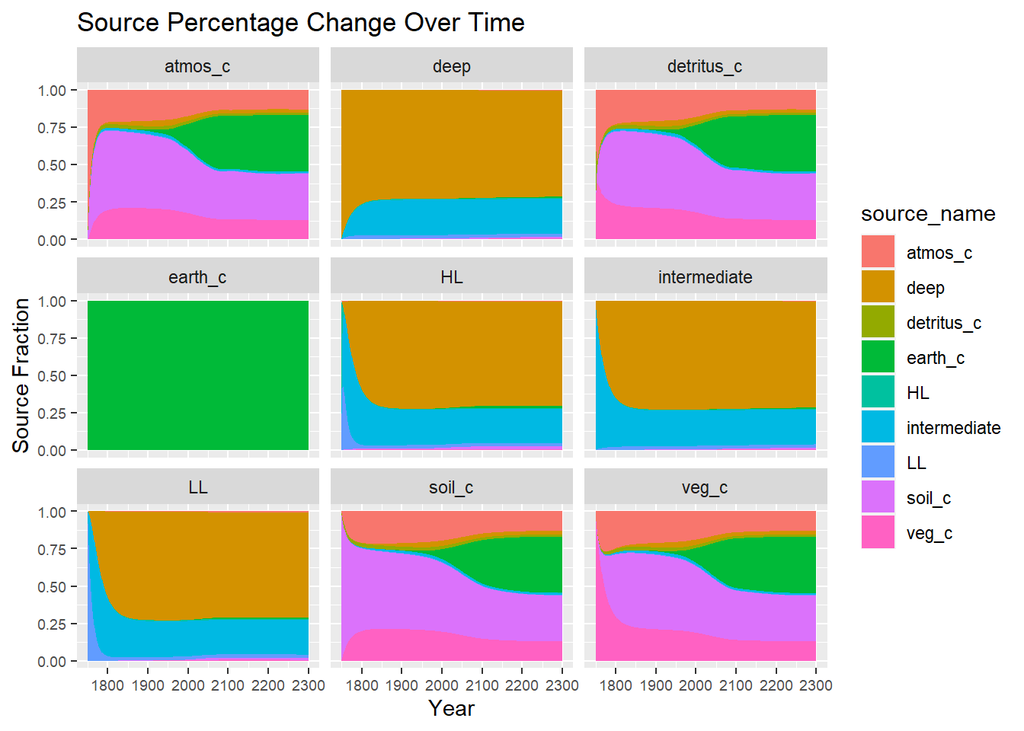

```r
ggplot(tdata, aes(year, source_fraction, fill = source_name)) +
  geom_area() +
  facet_wrap(~pool_name) +
  theme(axis.text = element_text(size = 7)) +
  labs(x = "Year",
       y = "Source Fraction",
       title = "Source Percentage Change Over Time")
```

Let’s examine just one pool:

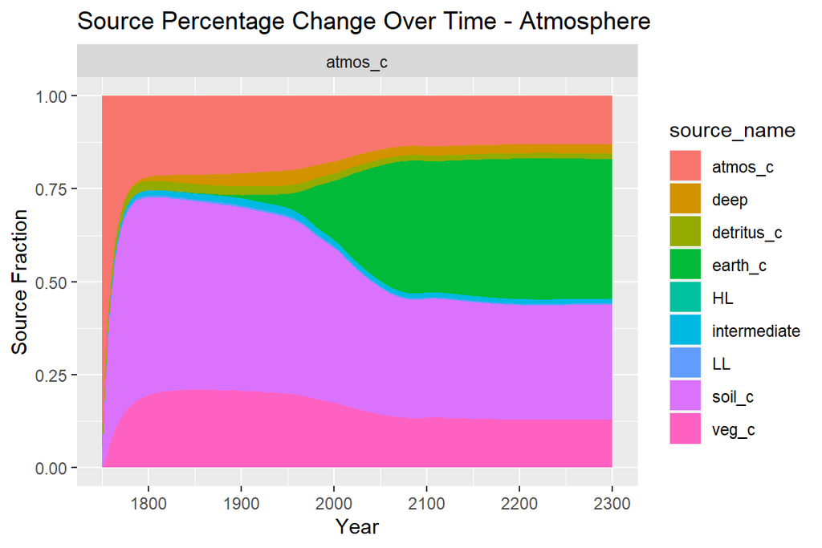

```r
atmos <- subset(tdata, pool_name == "atmos_c")
ggplot(atmos, aes(year, source_fraction, fill = source_name)) +
  geom_area() +
  facet_wrap(~pool_name) +
  labs(x = "Year",
       y = "Source Fraction",
       title = "Source Percentage Change Over Time - Atmosphere")
```

This allows us to better examine the contributions by source to the atmosphere.

## Example: Airborne fraction calculation

We can also use the tracking feature to calculate the airborne fraction for a given point in time, or how much carbon emitted by humans remains in the atmosphere as a fraction of total emissions as opposed to being absorbed by the land or ocean.

First, we can define two functions. The first will run a core and turn on tracking to return a data frame with results, including a column for the source amount by pool (as opposed to the source fraction). The second function will perform the airborne fraction calculation by finding the amount of `earth_c` (human emissions) in the `atmos_c` (atmosphere) pool at the start and end date of the run and dividing the difference by the difference in the `earth_c` pool from the start of the run to the end, i.e. how much carbon has left the `earth_c` pool.

```r
tracking_results <- function(inifile, start, stop, tracking, scenarioName) {
  # Establish core, turn on tracking, run core
  core <- newcore(inifile)
  setvar(core, NA, TRACKING_DATE(), tracking, "(unitless)")

  reset(core)
  run(core)

  # Get results, filter by correct years, add columns containing the amount of carbon by source and the given scenario name
  results <- get_tracking_data(core)
  results <- subset(results, year >= start)
  results <- subset(results, year <= stop)
  results$source_amount <- results$source_fraction * results$pool_value
  results$scenario_name <- scenarioName

  return(results)
}
AF_calc <- function(start, results, stop) {

  # Isolate the atmos_c pool and earth_c source in start/end years
  atm_c <- subset(results, results$pool_name == "atmos_c")
  atm_c <- subset(atm_c, atm_c$source_name == "earth_c")

  atm_c1 <- subset(atm_c, year == start)
  atm_c2 <- subset(atm_c, year == stop)
  atm_c <- rbind(atm_c1, atm_c2)

  # Calculate atmospheric uptake of Earth carbon
  atm_c <- tail(atm_c$source_amount, n = 1) - head(atm_c$source_amount, n = 1)
  # Isolate earth_c pool and source in start/end years
  earth_c_loss <- subset(results, results$pool_name == "earth_c")
  earth_c_loss <- subset(earth_c_loss, earth_c_loss$source_name == "earth_c")
  e_c1 <- subset(earth_c_loss, year == start)
  e_c2 <- subset(earth_c_loss, year == stop)
  earth_c_loss <- rbind(e_c1, e_c2)

  # Calculate change in Earth carbon
  earth_c_loss <- head(earth_c_loss$source_amount, n = 1) - tail(earth_c_loss$source_amount, n = 1)

  # Airborne fraction calculation
  AF <- atm_c / earth_c_loss

  return(AF)
}
```

Next, we will run our functions for the SSP245 scenario between 1750 and 2050 with tracking beginning at the start of the run. We can then find the value of the airborne fraction in any year of the model run. Let’s look at how the airborne fraction changes over time from 1950 to 2020 in ten year increments as well as the value in just the year 2020.

```r
ssp245 <- system.file("input", "hector_ssp245.ini", package = "hector")
results <- tracking_results(ssp245, 1750, 2050, 1750, "SSP245")
years <- seq(1950, 2020, by = 10)
airborne_frac <- cbind(make.row.names = years, lapply(years, AF_calc, results, 1750))
colnames(airborne_frac) <- c("year", "AF")
tail(airborne_frac, n = 1)
```

```
##      year AF
## [8,] 2020 0.4087177
```

We see that the airborne fraction in 2020 is about 41%, so 41% of anthropogenic emissions remain in the atmosphere.

We can compare these values to a study published by W. Knorr in 2009.[^2] Knorr computes seven values of airborne fractions in 2000 which we can average. We can compute the difference between the maximum value and the minimum to give an error range.

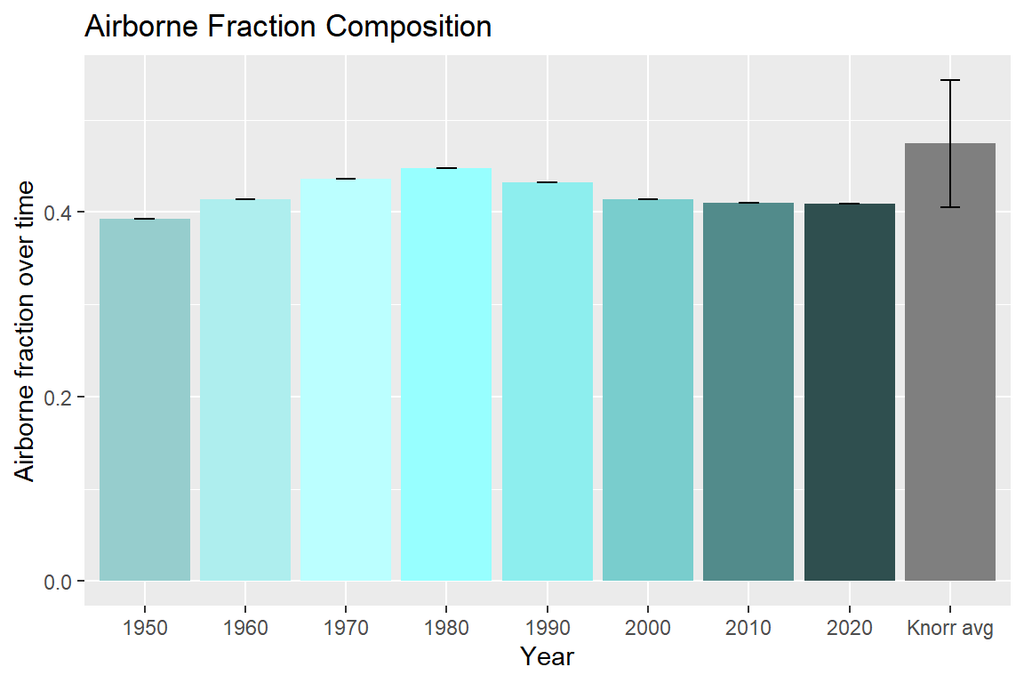

```r
# Knorr avg - values from Knorr 2009
knorr_values <- c(0.45, 0.453, 0.518, 0.468, 0.468, 0.514, 0.449)
knorr_avg <- mean(knorr_values)
knorr_minmax <- max(knorr_values) - min(knorr_values)
vars <- c("Knorr avg", years)
values <- c(knorr_avg, as.numeric(airborne_frac[,2]))
error <- c(knorr_minmax, rep(0, times = 8))
df <- data.frame(vars, values, error)
ggplot(df) +
  aes(x = vars, y = values, fill = vars) +
  geom_bar(stat = "identity") +
  geom_errorbar(aes(ymin = values - error, ymax = values + error), width = 0.2)+
  scale_fill_manual(values = c("paleturquoise3", "paleturquoise2", "paleturquoise1", "darkslategray1", "darkslategray2", "darkslategray3", "darkslategray4", "darkslategray", "grey50")) +
  theme(legend.position = "none") +
  labs(x = "Year",
       y = "Airborne fraction over time",
       title = "Airborne Fraction Composition")
```

## Conclusion

The carbon tracking feature allows users to identify and trace the composition by source of each pool in Hector. This is useful to, for example, calculate the model’s airborne fraction.

Remember to shut down the core.